# REGRESION LOGISTICA - TP 1

# Interpretacion del modelo

## 1) cargamos los paquetes que vamos a usar durante el análisis.

```r
library(data.table)
library(tidyverse)
library(broom)
library(vcd)
library(sjPlot)
library(epiR)
```

## 2) Traemos la base de datos desde la ubicacion donde vive

```r
setwd("~/Documents/DIEGO/PEC/LOGISTICA/Practicos")# recuerden cambiar la carpeta donde van a tener guardada la base de datos.
datos <- fread("framdata Ej 1.csv")
```

# Ejercicio

### Ajuste un modelo logístico entre enfermedad coronaria (Newchd) y age .

```r
datos$sex <- as.factor(datos$sex) # convertomos la variable sex a factor (categorica)

modelo1 <- glm(newchd ~ age, family = "binomial", data = datos)


t1<-tab_model(modelo1, show.se = T, show.dev = T, show.loglik = T, show.intercept = F,show.stat = F, show.reflvl = T, digits = 2, digits.p = 3, show.r2 = F,collapse.ci = F, title = "Newchd - EDAD")

knitr::asis_output(t1$knitr)
```

Newchd - EDAD

|  | newchd |  |  |  |
| --- | --- | --- | --- | --- |
| Predictors | Odds Ratios | std. Error | CI | p |
| age | 1.07 | 0.02 | 1.04 – 1.10 | **<0.001** |
| Observations | 1363 |  |  |  |
| Deviance | 1330.165 |  |  |  |
| log-Likelihood | -665.082 |  |  |  |

### Agregue luego la variable sex (hombre=1)

```r
modelo2 <- glm(newchd ~ age+sex,family = "binomial", data = datos)


t2<-tab_model(modelo2, show.se = T, show.dev = T, show.loglik = T, show.intercept = F,show.stat = F, show.reflvl = T, digits = 2, digits.p = 3, show.r2 = F,collapse.ci = F, title = "Newchd - SEX+EDAD")

knitr::asis_output(t2$knitr)
```

Newchd - SEX+EDAD

|  | newchd |  |  |  |
| --- | --- | --- | --- | --- |
| Predictors | Odds Ratios | std. Error | CI | p |
| age | 1.07 | 0.02 | 1.04 – 1.10 | **<0.001** |
| sex1 | 2.05 | 0.29 | 1.56 – 2.70 | **<0.001** |
| Observations | 1363 |  |  |  |
| Deviance | 1303.531 |  |  |  |
| log-Likelihood | -651.766 |  |  |  |

### Evalúe:

##### 1) Si la variable sex agrega valor predictivo al modelo. Como lo explica?

Si. El wald test es significativo y el log likelihood del modelo múltiple es mayor al del modelo simple >>>> una Deviance residual menor

##### 2) Como se interpreta el efecto de la edad en el modelo múltiple?

Ajustado por sexo, por cada año entre los 45 y los 62 (rango de edad en la base de datos) el log odds de EC aumenta 0,07 o el OR aumenta 1,07 (ANTILOG DE 0.07 = 1.07)

Recordar que la relación lineal es entre la edad como variable continua y el log odds de EC, y este incremento continuo esta representado por el coeficiente de edad (no por el OR). Para calcular el cambio por cada 10 años, se debe multiplicar el coeficiente 0,07 por 10 = 0,7 y a esa cantidad, aplicarle el antilogaritmo para obtener el OR de 10 años (= 2.01) Si se multiplica directamente el OR x 10, se obtiene un valor muy superior…

##### 3) Existe efecto confundidor de sex sobre la relación entre edad y enfermedad coronaria?

No, ya que el coeficiente para edad no se modifica con la entrada de sex al modelo.

##### 5) Existe interacción entre edad y sex?

```r
modelo3 <- glm(newchd ~ age+sex+age:sex,family = "binomial", data = datos)


t3<-tab_model(modelo3, show.se = T, show.dev = T, show.loglik = T, show.intercept = F,show.stat = F, show.reflvl = T, digits = 2, digits.p = 3, show.r2 = F,collapse.ci = T, title = "+ INTERACCION")

knitr::asis_output(t3$knitr)
```

INTERACCION

|  | newchd |  |  |
| --- | --- | --- | --- |
| Predictors | Odds Ratios | std. Error | p |
| age | 1.10 (1.05 – 1.16) | 0.03 | **<0.001** |
| age:sex1 | 0.95 (0.89 – 1.01) | 0.03 | 0.076 |
| sex1 | 34.63 (1.52 – 824.87) | 55.55 | **0.027** |
| Observations | 1363 |  |  |
| Deviance | 1300.364 |  |  |
| log-Likelihood | -650.182 |  |  |

El termino de interacción tiene una p 0,076, lo cual podría sugerir la presencia de una interacción entre edad y sexo en relación al riesgo de EC.

## modelo sin interaccion

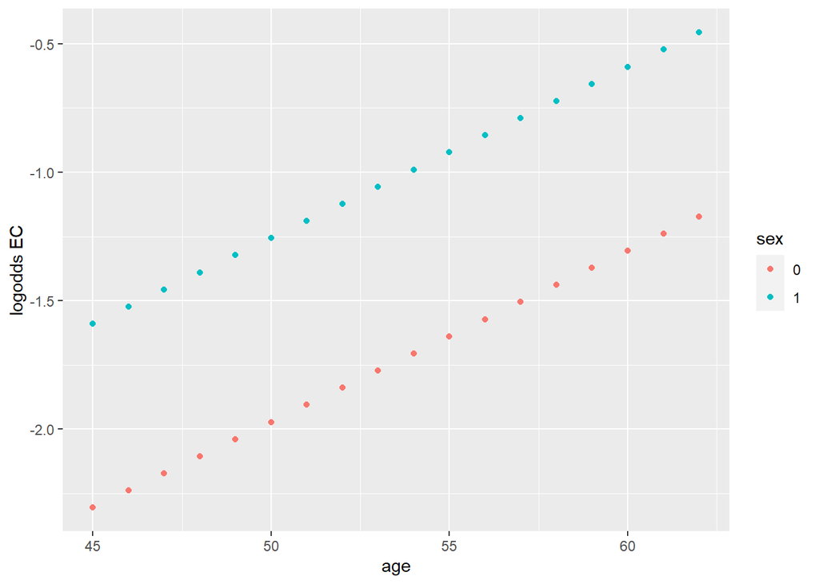

```r
datos %>% ggplot()+geom_point(aes(age,predict(modelo2, datos), color= sex))+ylab("logodds EC")
```

## modelo con termino de interaccion

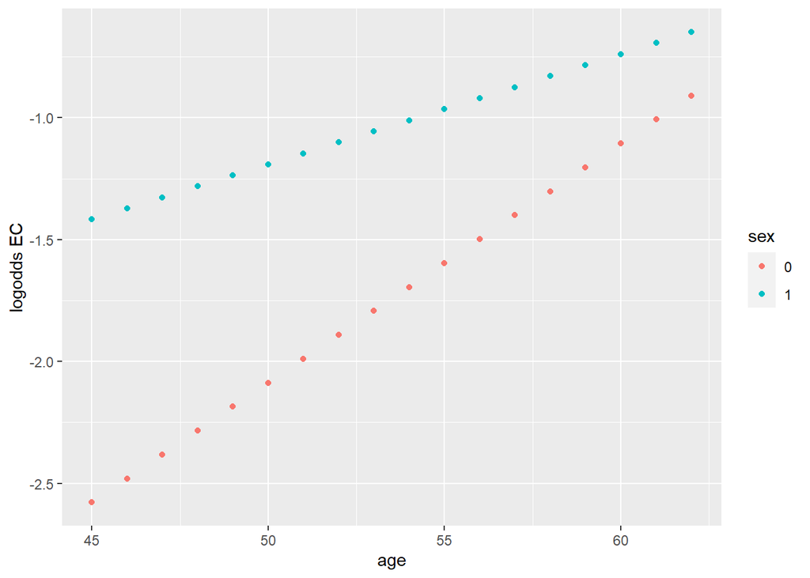

```r
datos %>% ggplot()+geom_point(aes(age,predict(modelo3, datos), color= sex))+ylab("logodds EC")
```

### Existe evidencia epidemiológica que sugiere algunas diferencias importantes entre hombres y mujeres con respecto al riesgo de EC. Una de ellas podría ser el efecto que la hipertensión sistólica tiene sobre la relacion entre sexo y EC.

```r
modelo4 <- glm(newchd ~ sbp,family = "binomial", data = datos)

t4<-tab_model(modelo4, show.se = T, show.dev = T, show.loglik = T, show.intercept = F,show.stat = F, show.reflvl = T, digits = 2, digits.p = 3, show.r2 = F,collapse.ci = T, title = "Newchd - SBP")

knitr::asis_output(t4$knitr)
```

Newchd - SBP

|  | newchd |  |  |
| --- | --- | --- | --- |
| Predictors | Odds Ratios | std. Error | p |
| sbp | 1.02 (1.01 – 1.02) | 0.00 | **<0.001** |
| Observations | 1363 |  |  |
| Deviance | 1305.048 |  |  |
| log-Likelihood | -652.524 |  |  |

```r
datos <- datos %>% mutate(sbp_cat = ifelse(sbp>=140,1,0))

modelo5 <- glm(newchd ~ sbp_cat,family = "binomial", data = datos)

t5<-tab_model(modelo5, show.se = T, show.dev = T, show.loglik = T, show.intercept = F,show.stat = F, show.reflvl = T, digits = 2, digits.p = 3, show.r2 = F,collapse.ci = T, title = "Newchd - SBP_CAT")
```

```r
modelo6 <- glm(newchd ~ sbp_cat+sex,family = "binomial", data = datos)

t6<-tab_model(modelo5,modelo6, show.se = T, show.dev = T, show.loglik = T, show.intercept = F,show.stat = F, show.reflvl = T, digits = 2, digits.p = 3, show.r2 = F,collapse.ci = T, title = "Newchd - SEX+SBP_CAT")

knitr::asis_output(t6$knitr)
```

Newchd - SEX+SBP_CAT

|  | newchd |  |  | newchd |  |  |
| --- | --- | --- | --- | --- | --- | --- |
| Predictors | Odds Ratios | std. Error | p | Odds Ratios | std. Error | p |
| sbp_cat | 2.20 (1.65 – 2.97) | 0.33 | **<0.001** | 2.40 (1.79 – 3.25) | 0.37 | **<0.001** |
| sex1 |  |  |  | 2.21 (1.68 – 2.93) | 0.31 | **<0.001** |
| Observations | 1363 |  |  | 1363 |  |  |
| Deviance | 1321.509 |  |  | 1289.353 |  |  |
| log-Likelihood | -660.755 |  |  | -644.676 |  |  |

### a) Mejora la predicción del modelo múltiple?

Si…..

```r
anova(modelo6, test = "LRT")
```

```
## Analysis of Deviance Table
##
## Model: binomial, link: logit
##
## Response: newchd
##
## Terms added sequentially (first to last)
##
##
##         Df Deviance Resid. Df Resid. Dev  Pr(>Chi)
## NULL                     1362     1351.2
## sbp_cat  1   29.736      1361     1321.5 4.950e-08 ***
## sex      1   32.157      1360     1289.3 1.422e-08 ***
## ---
## Signif. codes:  0 '***' 0.001 '**' 0.01 '*' 0.05 '.' 0.1 ' ' 1
```

### b) Evalúe si sex es un confundidor, un modificador de efecto o ambos de la relación entre sbp_cat y newchd. (Justifique su respuesta usando tablas de 2x2 y regresión logística).

El OR de sex varia 10% al ingresar sbp_cat en el modelo, lo que sugiere muy leve efecto confundidor de sbp_cat sobre la relacion entre sexo y EC.

#### Exposed: sbp_cat, Outcome: newchd, strata: sex.

- OR de EC sbp_cat = 2.2
- OR de EC sbp_cat (ajustado x sexo)= 2.4
- OR de EC sbp_cat [HOMBRES]= 1.93
- OR de EC sbp_cat [MUJERES]= 3.61

```r
a<-epi.2by2(table(exposure = datos$sbp_cat,outcome = datos$newchd, strata= datos$sex), method = "cohort.count", digits = 3, conf.level = 0.95, outcome = "as.columns", interpret = F)

a
```

```
##              Outcome +    Outcome -      Total                 Inc risk *
## Exposed +          495           73        568  87.148 (84.113 to 89.789)
## Exposed -          600          195        795  75.472 (72.327 to 78.426)
## Total             1095          268       1363  80.337 (78.126 to 82.417)
##
##
## Point estimates and 95% CIs:
## -------------------------------------------------------------------
## Inc risk ratio (crude)                         1.155 (1.098, 1.215)
## Inc risk ratio (M-H)                           1.170 (1.112, 1.230)
## Inc risk ratio (crude:M-H)                     0.987
## Odds ratio (crude)                             2.204 (1.642, 2.957)
## Odds ratio (M-H)                               2.424 (1.793, 3.279)
## Odds ratio (crude:M-H)                         0.909
## Attrib risk in the exposed (crude) *           11.676 (7.612, 15.741)
## Attrib risk in the exposed (M-H) *             12.701 (7.809, 17.594)
## Attrib risk (crude:M-H)                        0.919
## -------------------------------------------------------------------
##  M-H test of homogeneity of IRRs: chi2(1) = 0.048 Pr>chi2 = 0.826
##  M-H test of homogeneity of ORs: chi2(1) = 3.320 Pr>chi2 = 0.068
##  Test that M-H adjusted OR = 1:  chi2(1) = 34.007 Pr>chi2 = <0.001
##  Wald confidence limits
##  M-H: Mantel-Haenszel; CI: confidence interval
##  * Outcomes per 100 population units
```

```r
b<-a$massoc.detail$OR.strata.wald

row.names(b)<-c("sex_0", "sex_1")

b
```

```
##            est    lower    upper
## sex_0 3.614958 2.098408 6.227541
## sex_1 1.936641 1.338889 2.801261
```

```r
modelo7 <- glm(newchd ~ sbp_cat+sex+sbp_cat:sex,family = "binomial", data = datos)


t7<-tab_model(modelo7, show.se = T, show.dev = T, show.loglik = T, show.intercept = F,show.stat = F, show.reflvl = T, digits = 2, digits.p = 3, show.r2 = F,collapse.ci = T, title = "Newchd - SEX+SBP_CAT+INTERACCION")

knitr::asis_output(t7$knitr)
```

Newchd - SEX+SBP_CAT+INTERACCION

|  | newchd |  |  |
| --- | --- | --- | --- |
| Predictors | Odds Ratios | std. Error | p |
| sbp_cat | 3.61 (2.15 – 6.42) | 1.00 | **<0.001** |
| sbp_cat:sex1 | 0.54 (0.27 – 1.02) | 0.18 | 0.063 |
| sex1 | 3.50 (2.02 – 6.36) | 1.02 | **<0.001** |
| Observations | 1363 |  |  |
| Deviance | 1285.728 |  |  |
| log-Likelihood | -642.864 |  |  |

El efecto de sbp_cat sobre el riesgo de EC no es igual en hombres y en mujeres => Interacción clínicamente relevante con una p 0,06.

El OR de sbp_cat sobre EC en hombres es 1,93 y en las mujeres es 3,61. Si bien la diferencia de los OR no llega a ser estadísticamente significativa, la estimación sugiere un posible efecto de subgrupo (interacción) que debería ser considerado.

El efecto confundidor, si bien es modesto, pierde importancia ante la presencia de interacción.